# Analysis of Red Wine by Marc Maybaum

Studying oenology in college for a semester, I’ve become knowledgable in wine, but I thought it would be interesting to have the perspective of wine data to better understand wine in a different way.

```
##        X          fixed.acidity   volatile.acidity  citric.acid
##  Min.   :   1.0   Min.   : 4.60   Min.   :0.1200   Min.   :0.000
##  1st Qu.: 400.5   1st Qu.: 7.10   1st Qu.:0.3900   1st Qu.:0.090
##  Median : 800.0   Median : 7.90   Median :0.5200   Median :0.260
##  Mean   : 800.0   Mean   : 8.32   Mean   :0.5278   Mean   :0.271
##  3rd Qu.:1199.5   3rd Qu.: 9.20   3rd Qu.:0.6400   3rd Qu.:0.420
##  Max.   :1599.0   Max.   :15.90   Max.   :1.5800   Max.   :1.000
##  residual.sugar     chlorides       free.sulfur.dioxide
##  Min.   : 0.900   Min.   :0.01200   Min.   : 1.00
##  1st Qu.: 1.900   1st Qu.:0.07000   1st Qu.: 7.00
##  Median : 2.200   Median :0.07900   Median :14.00
##  Mean   : 2.539   Mean   :0.08747   Mean   :15.87
##  3rd Qu.: 2.600   3rd Qu.:0.09000   3rd Qu.:21.00
##  Max.   :15.500   Max.   :0.61100   Max.   :72.00
##  total.sulfur.dioxide    density             pH          sulphates
##  Min.   :  6.00       Min.   :0.9901   Min.   :2.740   Min.   :0.3300
##  1st Qu.: 22.00       1st Qu.:0.9956   1st Qu.:3.210   1st Qu.:0.5500
##  Median : 38.00       Median :0.9968   Median :3.310   Median :0.6200
##  Mean   : 46.47       Mean   :0.9967   Mean   :3.311   Mean   :0.6581
##  3rd Qu.: 62.00       3rd Qu.:0.9978   3rd Qu.:3.400   3rd Qu.:0.7300
##  Max.   :289.00       Max.   :1.0037   Max.   :4.010   Max.   :2.0000
##     alcohol         quality
##  Min.   : 8.40   Min.   :3.000
##  1st Qu.: 9.50   1st Qu.:5.000
##  Median :10.20   Median :6.000
##  Mean   :10.42   Mean   :5.636
##  3rd Qu.:11.10   3rd Qu.:6.000
##  Max.   :14.90   Max.   :8.000
```

> The dataset consists of 1599 observations and 13 variables

# Univariate Plots Section

### Alcohol Histogram

> The average alcohol percentage is 10.42%. The majority of wines are above 8% and less than 14%.

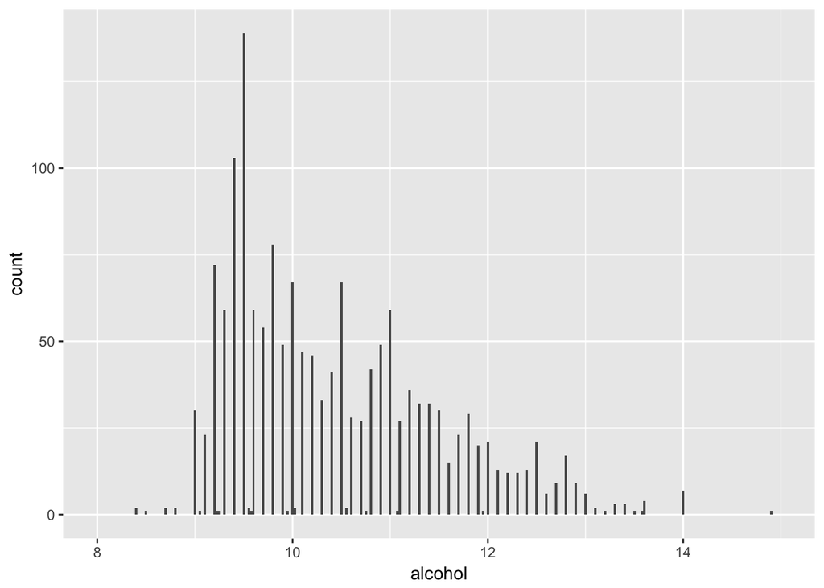

### Density Histogram

> Density has an even distribution with wines having a mean density of 0.9967.

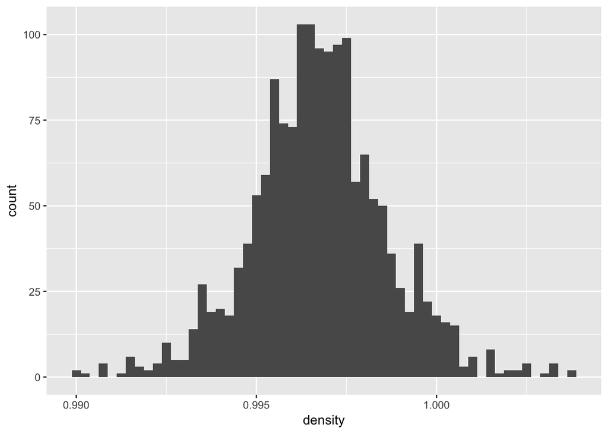

### pH Histogram

> pHs have little variation with a minimum value of 2.74 and a maximum of 4.01.

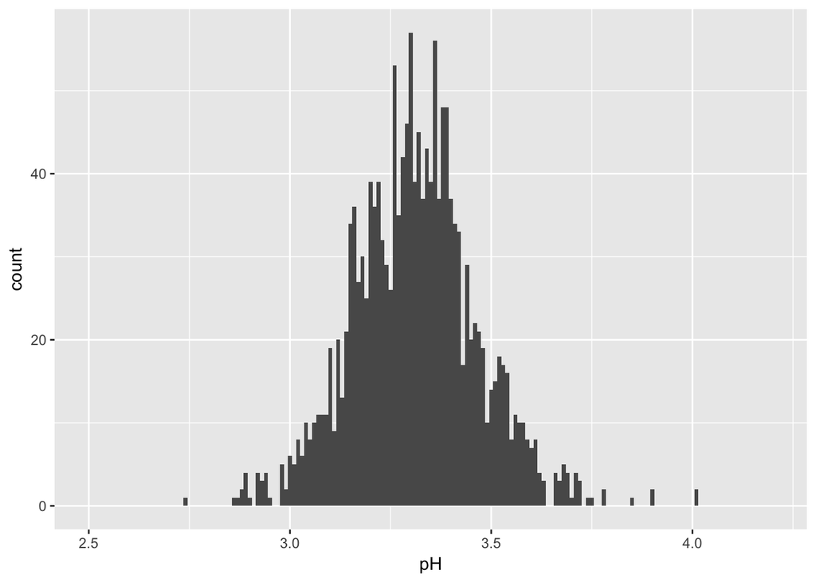

### Total Sulfur Dioxide Histogram

> Total Sulfur Dioxide is positively skewed. To see if there is a clearer picture of the measurement, I am going to visualize the log of it. Total Sulfur Dioxide has more of a normal distribution after taking the log of the measurement.

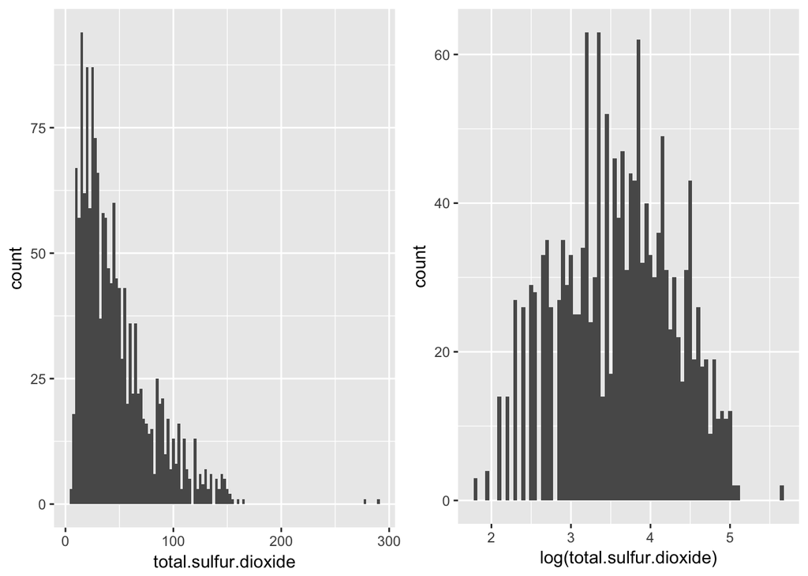

### Sulphates Histogram

> The majority of sulphates are bunched between 0 and 1.

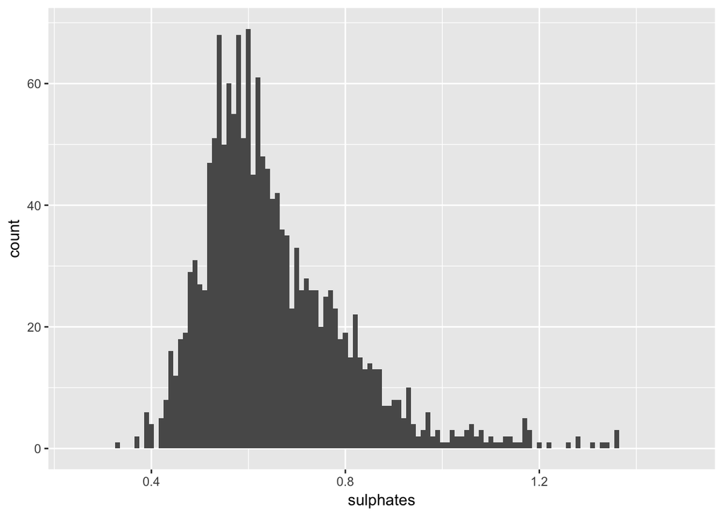

### Residual Sugar Histogram

> The histogram of residual sugar was positively skewed. Upon taking the log of residual sugar, we get a distribution closer to a normal distribution with a tail at the end of the x axis.

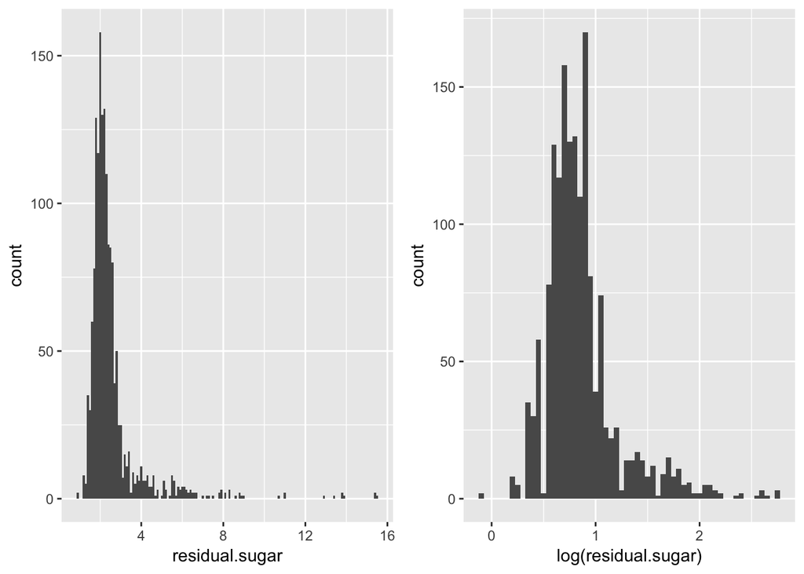

> Zooming in to view the normal distribution between 0.25 & 4, we can see that it is likely for the residual sugars to fall between 0 and 4, though there are other wines with higher concentrations of residual sugars (ports and dessert wines).

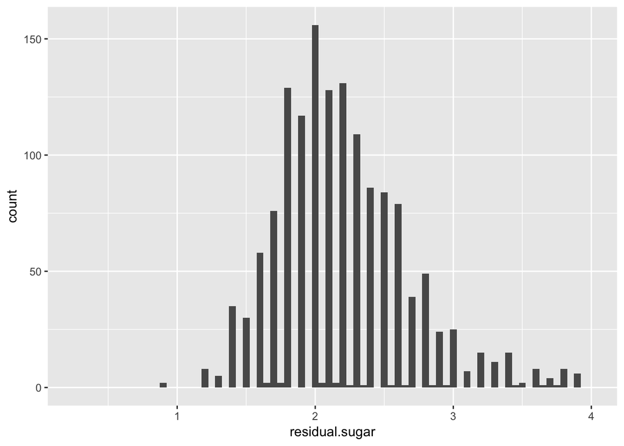

### Quality Histogram

> Quality is measured in whole numbers causing the histogram to bunch up no matter the binwidth.

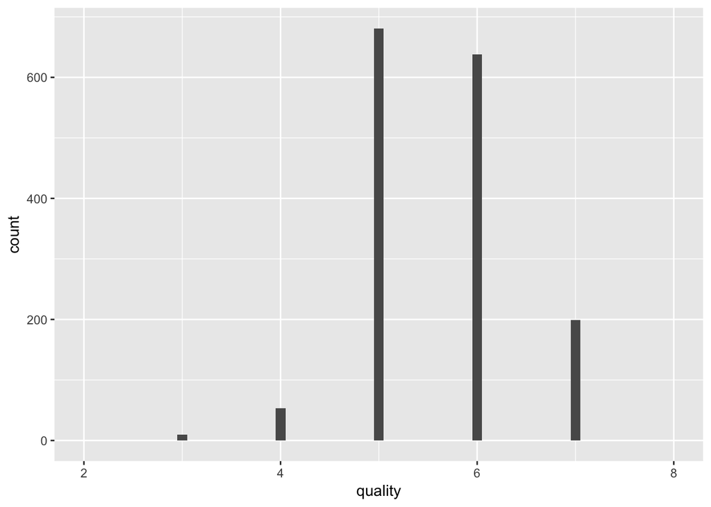

```
##    Min. 1st Qu.  Median    Mean 3rd Qu.    Max.
##   3.000   5.000   6.000   5.636   6.000   8.000
```

# Univariate Analysis

### What is the structure of your dataset?

Red Wine dataset is made up of 1599 observations and 13 variables (Fixed Acidity, Volatile Acidity, Citric Acid, Residual Sugar, Chlorides, Free Sulfur Dioxide, Total Sulfur Dioxide, Density, pH, Sulphates, Alcohol, Quality). Observations thus far:

- Alcohol levels vary between 8% and 14%
- Many wines have similar pH levels (between 2.74 & 4.01)
- The majority of wines have less than 1.0 sulphates
- The quality for wines vary, but the median rating is 6

### What is/are the main feature(s) of interest in your dataset?

My main interest in the dataset is quality of wine. If any of the variables will have a relationship with quality of wine, I think it would be acidity or sulphates.

### What other features in the dataset do you think will help support your investigation into your feature(s) of interest?

I think it will be rare to find a strong relationship between many of the measurements (alcohol %, pH, sulphates, residual sugars, and acidity) and quality. My hunch is that acidity will have the strongest relationship with quality score.

### Did you create any new variables from existing variables in the dataset?

Nope

### Of the features you investigated, were there any unusual distributions? Did you perform any operations on the data to tidy, adjust, or change the form of the data? If so, why did you do this?

Both Total Sulfur Dioxide and Residual Sugars had a positive skew visualization. Upon transforming the data using the log() formula, the distribution of the data became more normally distributed appearing. I did this to see if I could have a better understanding of the data without having the outlying data impact the visualization seen.

# Bivariate Plots Section

> First, I want to calculate the Pearson Correlation Coefficient to find out if there is any relationship between the variables. I will first create a table of all these calculations and then turn the table into multiple visualizations.

```
##                                 X fixed.acidity volatile.acidity
## X                     1.000000000   -0.26848392     -0.008815099
## fixed.acidity        -0.268483920    1.00000000     -0.256130895
## volatile.acidity     -0.008815099   -0.25613089      1.000000000
## citric.acid          -0.153551355    0.67170343     -0.552495685
## residual.sugar       -0.031260835    0.11477672      0.001917882
## chlorides            -0.119868519    0.09370519      0.061297772
## free.sulfur.dioxide   0.090479643   -0.15379419     -0.010503827
## total.sulfur.dioxide -0.117849669   -0.11318144      0.076470005
## density              -0.368372087    0.66804729      0.022026232
## pH                    0.136005328   -0.68297819      0.234937294
## sulphates            -0.125306999    0.18300566     -0.260986685
## alcohol               0.245122841   -0.06166827     -0.202288027
## quality               0.066452608    0.12405165     -0.390557780
##                      citric.acid residual.sugar    chlorides
## X                    -0.15355136   -0.031260835 -0.119868519
## fixed.acidity         0.67170343    0.114776724  0.093705186
## volatile.acidity     -0.55249568    0.001917882  0.061297772
## citric.acid           1.00000000    0.143577162  0.203822914
## residual.sugar        0.14357716    1.000000000  0.055609535
## chlorides             0.20382291    0.055609535  1.000000000
## free.sulfur.dioxide  -0.06097813    0.187048995  0.005562147
## total.sulfur.dioxide  0.03553302    0.203027882  0.047400468
## density               0.36494718    0.355283371  0.200632327
## pH                   -0.54190414   -0.085652422 -0.265026131
## sulphates             0.31277004    0.005527121  0.371260481
## alcohol               0.10990325    0.042075437 -0.221140545
## quality               0.22637251    0.013731637 -0.128906560
##                      free.sulfur.dioxide total.sulfur.dioxide     density
## X                            0.090479643          -0.11784967 -0.36837209
## fixed.acidity               -0.153794193          -0.11318144  0.66804729
## volatile.acidity            -0.010503827           0.07647000  0.02202623
## citric.acid                 -0.060978129           0.03553302  0.36494718
## residual.sugar               0.187048995           0.20302788  0.35528337
## chlorides                    0.005562147           0.04740047  0.20063233
## free.sulfur.dioxide          1.000000000           0.66766645 -0.02194583
## total.sulfur.dioxide         0.667666450           1.00000000  0.07126948
## density                     -0.021945831           0.07126948  1.00000000
## pH                           0.070377499          -0.06649456 -0.34169933
## sulphates                    0.051657572           0.04294684  0.14850641
## alcohol                     -0.069408354          -0.20565394 -0.49617977
## quality                     -0.050656057          -0.18510029 -0.17491923
##                               pH    sulphates     alcohol     quality
## X                     0.13600533 -0.125306999  0.24512284  0.06645261
## fixed.acidity        -0.68297819  0.183005664 -0.06166827  0.12405165
## volatile.acidity      0.23493729 -0.260986685 -0.20228803 -0.39055778
## citric.acid          -0.54190414  0.312770044  0.10990325  0.22637251
## residual.sugar       -0.08565242  0.005527121  0.04207544  0.01373164
## chlorides            -0.26502613  0.371260481 -0.22114054 -0.12890656
## free.sulfur.dioxide   0.07037750  0.051657572 -0.06940835 -0.05065606
## total.sulfur.dioxide -0.06649456  0.042946836 -0.20565394 -0.18510029
## density              -0.34169933  0.148506412 -0.49617977 -0.17491923
## pH                    1.00000000 -0.196647602  0.20563251 -0.05773139
## sulphates            -0.19664760  1.000000000  0.09359475  0.25139708
## alcohol               0.20563251  0.093594750  1.00000000  0.47616632
## quality              -0.05773139  0.251397079  0.47616632  1.00000000
```

> The below is a heatmap of the different variables and how correlated they are to one another (seen above). When the variable is compared to itself, the correlation is a perfect 1. This design can be seen diagonally in the visual.

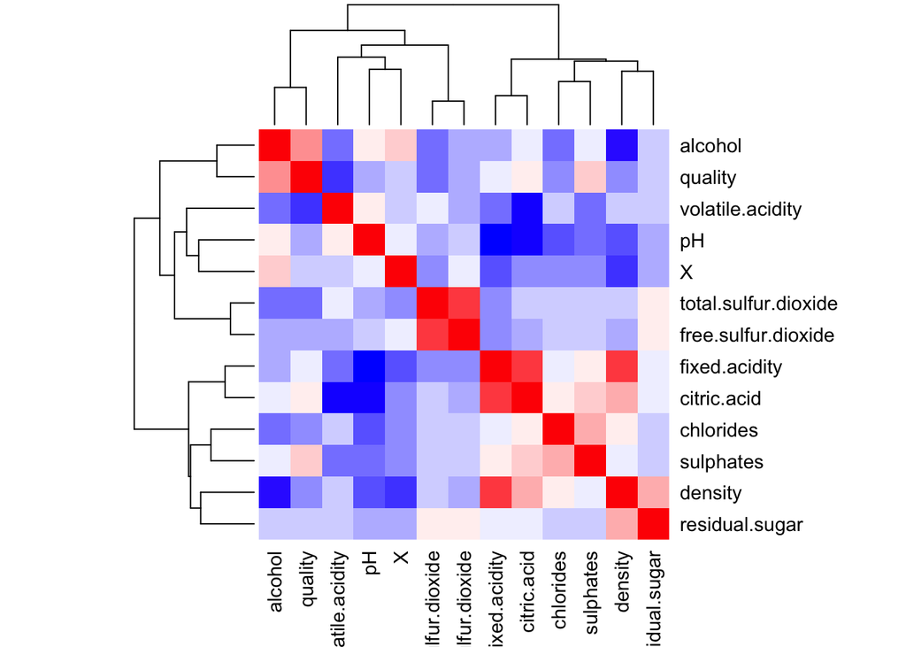

> Of the relationships, the strongest positive correlations are between acids and sulfur measurements. Citric acid & fixed acid and free sulfur dioxide & total sulfur dioxide are the strongest positively correlated variables. Additionally, of the negatively correlated relationships, pH & citric acid and pH & fixed acidity are very strong relationships.

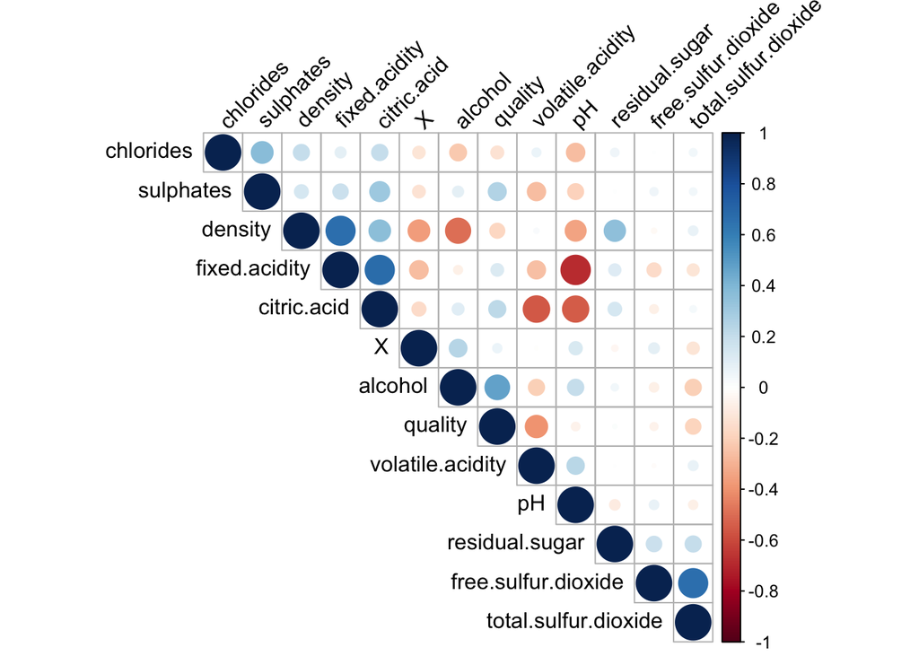

> Further looking into these relationships in the above visualization, it is easier to view the stronger relationships based on the size and opaqueness of the circle. Some additional relationships that were not identified previously include negative relationships between alchol & density and volatile acidity & citric acid.

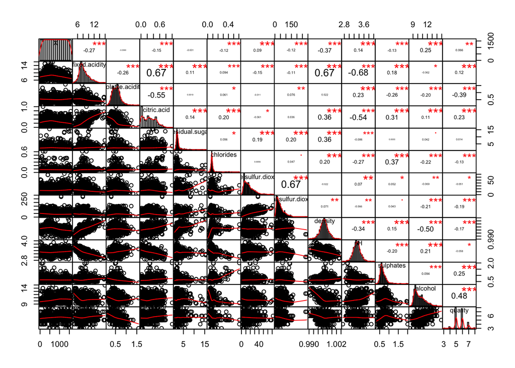

> Lastly, I’ve created a correlation chart that is able to showcase the correlation coefficients with a scatterplot of the two variables. We can see many of the stronger correlations identified earlier in the other visualizations.

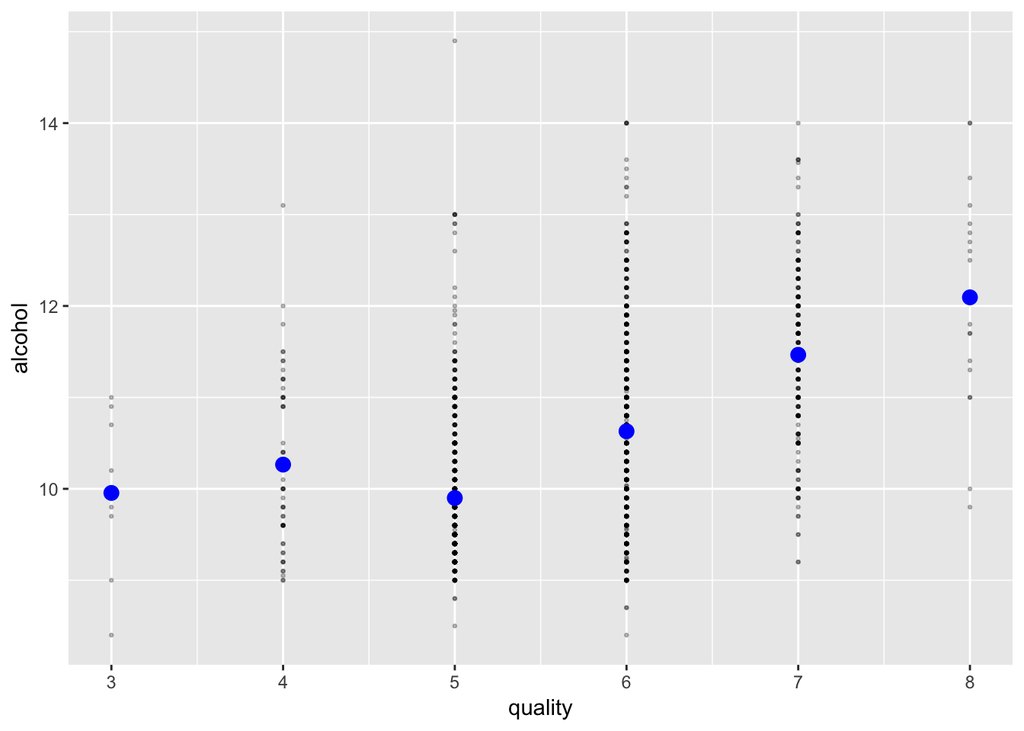

> Looking into the strongest relationships for quality & red wine variables, I’ve created scatter plots with the mean highlighted in blue between Alcohol & Quality (above) and Volatile Acidity & Quality (below).

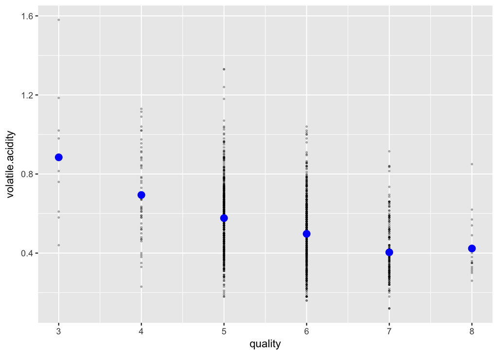

# Bivariate Analysis

### How did the feature(s) of interest vary with other features in the dataset?

Quality showed very weak relationships between many variables in the dataset. Of the strongest relationships, Alcohol & Quality showed a moderate positive relationship (r^2 value of 0.48) and Volatile Acidity & Quality had a moderate negative relationship (r^2 value of -0.39). These two observations are interesting because it gives clues to potential requirements of what a wine taster expects from a quality wine - a threshold of alcohol (possibly to balance the wine profile) and lower levels of Volatile Acidity (possible expectation for how much acid should be contained in a wine). Because the Pearson value is only a moderate relationship for both of these relationships, this also implies that these expectations are not consistently held between tasters compared to if a strong relationship would exist. Both of these observations can be seen in the above bivariate plots - mean Alcohol level increases as Quality increases and mean Voltaile Acidity decreases as Quality of Wine increases.

### Did you observe any interesting relationships between the other features (not the main feature(s) of interest)?

All of the strongest relationships came from variables other than my main focus of interest. In fact, quality of wine (as expected) is not strongly correlated with any of the variables supplied in this dataset. My strongest relationships were between pH & Fixed Acidity (r^2 value of -0.68), Fixed Acidity & Density (r^2 value of 0.67), Fixed Acidity & Citric Acid (r^2 value of 0.67), and Free Sulfur Dioxide & Total Sulfur Dioxide (r^2 value of 0.67).

### What was the strongest relationship you found?

The strongest relationship was between pH and Fixed Acidity at -0.68

# Multivariate Plots Section

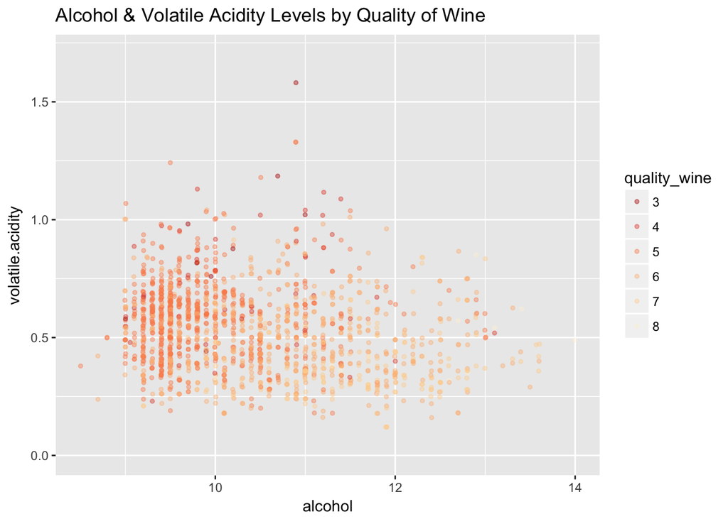

> When graphing Voltatile Acidity & Alcohol by Quality of Wine, it is noticeable that the lowest quality wines are grouped together in the lower alcohol level of the graph with a higher variation and higher levels of volatile acidity, and the higher quality wines are grouped together in the higher levels of alcohol percentage and lower levels of volatile acidity. This visualization is also in line with the correlation levels between each variable and quality of wine found in the bivariate plots section.

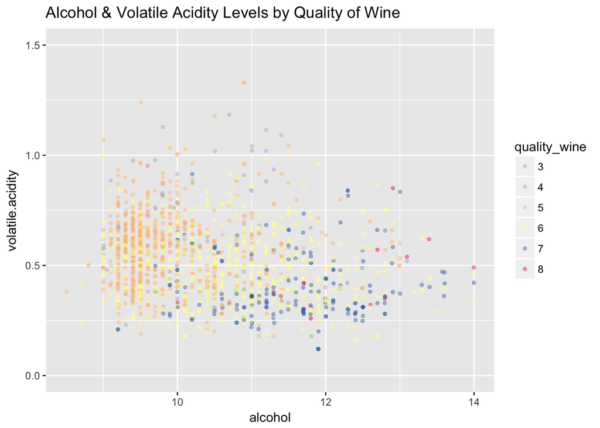

> Graphing the same variables with a different color variation shows the same observation previously identified - high quality wines are seen, generally, in the lower, right hand corner of the graph with yellow, blue, and magenta points. It is noticeable that higher alcohol and lower and less varied volatile acidity levels are the common themes for higher quality wines, though there are few of these wines compared to the rest of the dataset (see below).

```
## [1] "Count of Quality Score"
```

```
##
##   3   4   5   6   7   8
##  10  53 681 638 199  18
```

> After understanding the relationship between Quality & Alcohol and Quality & Volatile Acidity, let’s see how well we can create and train a model with the top 5 correlated variables for quality of wine.

```
##
## Calls:
## m1: lm(formula = (I(quality) ~ I(alcohol)), data = redwine)
## m2: lm(formula = I(quality) ~ I(alcohol) + volatile.acidity, data = redwine)
## m3: lm(formula = I(quality) ~ I(alcohol) + volatile.acidity + sulphates,
##     data = redwine)
## m4: lm(formula = I(quality) ~ I(alcohol) + volatile.acidity + sulphates +
##     citric.acid, data = redwine)
## m5: lm(formula = I(quality) ~ I(alcohol) + volatile.acidity + sulphates +
##     citric.acid + total.sulfur.dioxide, data = redwine)
##
## ==============================================================================================
##                              m1            m2            m3            m4            m5
## ----------------------------------------------------------------------------------------------
##   (Intercept)               1.875***      3.095***      2.611***      2.646***      2.843***
##                            (0.175)       (0.184)       (0.196)       (0.201)       (0.205)
##   I(alcohol)                0.361***      0.314***      0.309***      0.309***      0.295***
##                            (0.017)       (0.016)       (0.016)       (0.016)       (0.016)
##   volatile.acidity                       -1.384***     -1.221***     -1.265***     -1.222***
##                                          (0.095)       (0.097)       (0.113)       (0.112)
##   sulphates                                             0.679***      0.696***      0.721***
##                                                        (0.101)       (0.103)       (0.103)
##   citric.acid                                                        -0.079        -0.043
##                                                                      (0.104)       (0.104)
##   total.sulfur.dioxide                                                             -0.002***
##                                                                                    (0.001)
## ----------------------------------------------------------------------------------------------
##   R-squared                 0.227         0.317         0.336         0.336         0.344
##   adj. R-squared            0.226         0.316         0.335         0.334         0.342
##   sigma                     0.710         0.668         0.659         0.659         0.655
##   F                       468.267       370.379       268.912       201.777       166.962
##   p                         0.000         0.000         0.000         0.000         0.000
##   Log-likelihood        -1721.057     -1621.814     -1599.384     -1599.093     -1589.749
##   Deviance                805.870       711.796       692.105       691.852       683.814
##   AIC                    3448.114      3251.628      3208.768      3210.186      3193.499
##   BIC                    3464.245      3273.136      3235.654      3242.448      3231.138
##   N                      1599          1599          1599          1599          1599
## ==============================================================================================
```

```
##
## Call:
## lm(formula = I(quality) ~ I(alcohol) + volatile.acidity + sulphates +
##     citric.acid + total.sulfur.dioxide, data = redwine)
##
## Residuals:
##      Min       1Q   Median       3Q      Max
## -2.72463 -0.38380 -0.06689  0.44606  2.14550
##
## Coefficients:
##                        Estimate Std. Error t value Pr(>|t|)
## (Intercept)           2.8431068  0.2050732  13.864  < 2e-16 ***
## I(alcohol)            0.2953419  0.0160375  18.416  < 2e-16 ***
## volatile.acidity     -1.2223102  0.1124774 -10.867  < 2e-16 ***
## sulphates             0.7207881  0.1027039   7.018 3.32e-12 ***
## citric.acid          -0.0427246  0.1035810  -0.412     0.68
## total.sulfur.dioxide -0.0022182  0.0005126  -4.327 1.60e-05 ***
## ---
## Signif. codes:  0 '***' 0.001 '**' 0.01 '*' 0.05 '.' 0.1 ' ' 1
##
## Residual standard error: 0.6552 on 1593 degrees of freedom
## Multiple R-squared:  0.3439, Adjusted R-squared:  0.3418
## F-statistic:   167 on 5 and 1593 DF,  p-value: < 2.2e-16
```

```
##        fit      lwr      upr
## 1 631.8945 174.3488 2290.183
```

> As can be seen in the r-squared output & the model’s prediction for a quality score with an example dataset, the relationships between the variables in the red_wine dataset are not strong enough to predict the quality score of a wine. Even with the 5 strongest relationships accounted for, we are only able to reach a 0.344 r-squared value for the model. Unfortunately, this model needs stronger relationships and a larger data set to be trained and give an accurate prediction.

# Multivariate Analysis

### Talk about some of the relationships you observed in this part of the investigation. Were there features that strengthened each other in terms of looking at your feature(s) of interest?

The moderate linear relationships between quality & alcohol/volatile acid showcased the pattern that each individual relationship had on quality. Although because the relationships were moderate, sometimes these visualizations were harder to showcase. High quality wines in particular had a general pattern, but needed a lot more data to substantiate visually.

### Were there any interesting or surprising interactions between features?

After viewing the correlations in multiple visualizations, it was pretty obvious how variables interacted with one another. If anything, the multivariate analysis showcased the weakness of a lot of the variables’ relationship with quality score.

### Did you create any models with your dataset? Discuss the strengths and limitations of your model.

I created a model with the weak relationships of the variables to quality. As expected, the model had a weak coefficient to predicting future results with only an r-squared value of 0.344. The prediction output wasn’t even within the range of quality scores in the dataset. Much more data and stronger relationships would help the model gain a higher r-squared value and a more accurate expected output.

# Final Plots and Summary

### Plot One

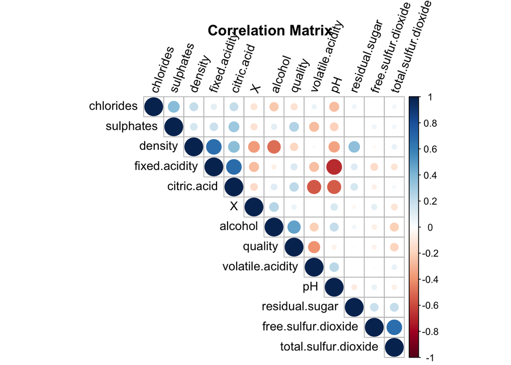

### Description One

The correlatioin matrix shows how strong of a relationship two variables from the red_wine dataset have based on the r-squared value. The opaqueness and size of the circle symbolizes the strength of the relationship.

### Plot Two

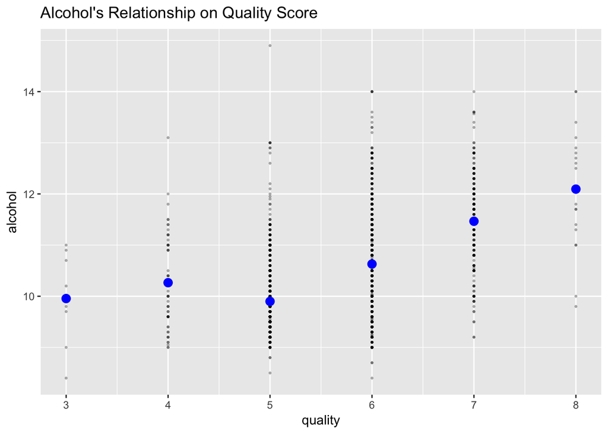

### Description Two

As can be seen in this scatter plot, alcohol and quality are plotted against one another. Additionally, the mean amount of alcohol in each quality score is visualized with a blue dot. As shown in the correlation matrix, alcohol has one of the stronger positive relationships with quality score of all the variables.

### Plot Three

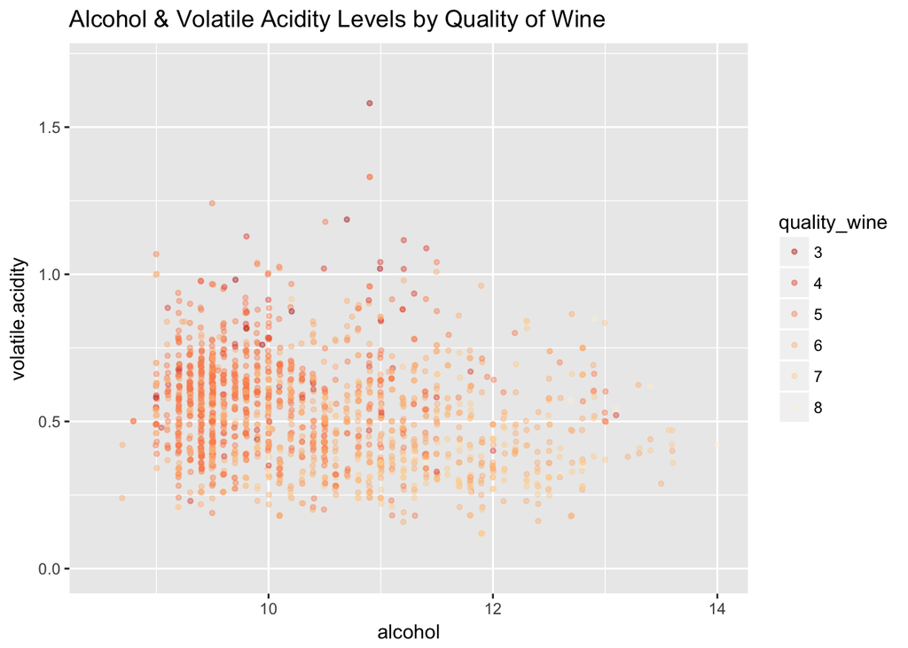

### Description Three

The scatter plot of volatile acidity & alcohol colored by the quality score of the entry shows the common traits of a quality wine based on these two traits. Of the low quality scores, wines have a lower alcohol percentage and a higher amount of volatile acidity than highly scored wines. The low quality wines can be seen in the upper left portion of the scatter plot, while the high quality wines are not as visible in the lower, right area of the scatter plot.

# Reflections

After exploring the Red Wine dataset I have learned about wine in ways I did not expect. The biggest lesson is that it is very tough to know how a wine will be received by the consumer based on pure data measurements. Though there are some common variables for a higher quality score, like a low amount of volatile acidity and at least a mean amount of alcohol, there is still much that could be learned from a larger data set and measurements. I think I was cautious enough when exploring the data to not make many assumptions and dug into the correct data available to analyze quality score.

My difficulties were most significant when trying to develop a model based on the available data. There were both not enough significant relationships and enough data to train the model to accurately predict quality score ratings. In the future, enriching the data with more collection and new measurements could possibly help train the model to predict quality score.